# Hands-on Time Series Analysis with R

Author

Rick Dean

Abstract

The following notes/scripts/plots are inspired by chapter 3 ‘The Time Series Object’ of the book [Hands-on Time Series Analysis with R](https://github.com/PacktPublishing/Hands-On-Time-Series-Analysis-with-R) by Rami Krispin

```r
library(data.table)
library(astsa)
library(magrittr)
library(RplotterPkg)
library(RtsaPkg)
```

# 3 The Time Series Object

## 3.1 The Natural Gas Consumption dataset

Load and plot the natural gas `ts` time series.

```r
apath <- file.path(here::here(), "Hands-on Time Series Analysis with R", "data", "USgas.rda")
load(apath)
str(USgas)
```

```
 Time-Series [1:238] from 2000 to 2020: 2510 2331 2051 1783 1633 ...
```

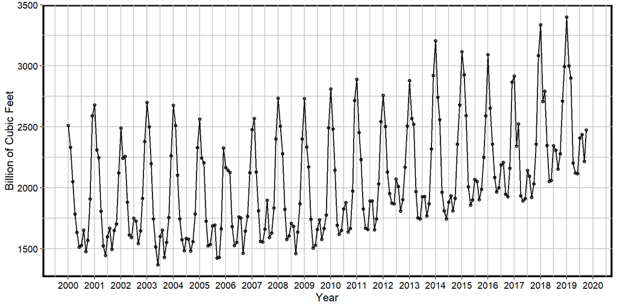

US monthly natural gas consumption

```r
USgas_dt <- RtsaPkg::tsObj_to_dt(USgas) %>%
  data.table::setnames(old = c("time","value"), c("Date","Gas_Consumption"))

RplotterPkg::create_scatter_plot(
  df = USgas_dt,
  aes_x = "Date",
  aes_y = "Gas_Consumption",
  x_major_date_breaks = "1 year",
  x_date_labels = "%Y",
  connect = TRUE,
  x_title = "Year",
  y_title = "Billion of Cubic Feet",
  rot_y_tic_label = TRUE
)
```

## 3.2 The attributes of the *ts* class.

> A “ts” object is composed of two elements–the series values and its corresponding timestamp. It has several attributes such as the series, cycle, frequency, and the time interval between each consecutive observation.

The class and structure of *USgas* time series.

```r
base::cat("USgas class: ", class(USgas), "\n")
```

```
USgas class:  ts
```

```r
base::cat("USgas 'is.ts':", is.ts(USgas), "\n")
```

```
USgas 'is.ts': TRUE
```

```r
base::cat("USgas length:", length(USgas), "\n")
```

```
USgas length: 238
```

```r
str(USgas)
```

```
 Time-Series [1:238] from 2000 to 2020: 2510 2331 2051 1783 1633 ...
```

The `USgas` time series is a monthly ts time series that starts in Janurary 2000 and ends October 2019. We are covering 19 years with a total of 238 months.

The `stats::cycle()` and `stats::time()` functions for *USgas*.

```r
base::cat("'head(cycle(USgas), 13)':", head(cycle(USgas), 13), "\n")
```

```
'head(cycle(USgas), 13)': 1 2 3 4 5 6 7 8 9 10 11 12 1
```

```r
base::cat("'head(time(USgas), 13))':", head(time(USgas), 13), "\n")
```

```
'head(time(USgas), 13))': 2000 2000.083 2000.167 2000.25 2000.333 2000.417 2000.5 2000.583 2000.667 2000.75 2000.833 2000.917 2001
```

```r
RplotterPkg::create_table(
  x = RtsaPkg::get_series_info(USgas)$stats,
  container_width_px = 400
)
```

Time series information of USgas

| name | class | delta | start | end | freq | length | nvar |
| --- | --- | --- | --- | --- | --- | --- | --- |
| USgas | ts | 0.08333333 | 2000 1 | 2019 10 | 12 | 238 | 1 |

Show the attributes of the US GDP quarterly dataset.

The `astsa::gdp` ts time series is a seasonally adjusted quarterly U.S. GDP from 1947(1) to 2018(3).

The class and structure of *gdp_ts*.

```r
gdp_ts <- astsa::gdp
base::cat("gdp_ts class: ", class(gdp_ts), "\n")
```

```
gdp_ts class:  ts
```

```r
base::cat("gdp_ts 'is.ts':", is.ts(gdp_ts), "\n")
```

```
gdp_ts 'is.ts': TRUE
```

```r
base::cat("gdp_ts length:", length(gdp_ts), "\n")
```

```
gdp_ts length: 287
```

```r
base::cat("'str(gdp_ts)':",str(gdp_ts),"\n")
```

```
 Time-Series [1:287] from 1947 to 2018: 2033 2028 2023 2055 2086 ...
'str(gdp_ts)':
```

```r
base::cat("'head(gdp_ts,4)':", head(gdp_ts,4), "\n")
```

```
'head(gdp_ts,4)': 2033.061 2027.639 2023.452 2055.103
```

The `stats::cycle()` and `stats::time()` functions for *gdp_ts*.

```r
base::cat("'head(cycle(gdp_ts), 8)':", head(cycle(gdp_ts), 8), "\n")
```

```
'head(cycle(gdp_ts), 8)': 1 2 3 4 1 2 3 4
```

```r
base::cat("'head(time(gdp_ts), 8))':", head(time(gdp_ts), 8), "\n")
```

```
'head(time(gdp_ts), 8))': 1947 1947.25 1947.5 1947.75 1948 1948.25 1948.5 1948.75
```

> As you can see, the timestamp is a decimal number that is aligned with the cycles of the series. The values on the left-hand side of the decimal point represent the cycle number(in this case, the calendar year), and the values on the right-side represent the cycle units, where the count of the units starts from 0.

The `stats::frequency()` and `stats::deltat()` functions for *gdp_ts*.

```r
base::cat("'frequency(gdp_ts)':", frequency(gdp_ts), "\n")
```

```
'frequency(gdp_ts)': 4
```

```r
base::cat("'delta(gdp_ts)':", deltat(gdp_ts), "\n")
```

```
'delta(gdp_ts)': 0.25
```

The `stats::start()` and `stats::end()` functions for *gdp_ts*.

```r
base::cat("'start(gdp_ts)':", start(gdp_ts), "\n")
```

```
'start(gdp_ts)': 1947 1
```

```r
base::cat("'end(gdp_ts)':", end(gdp_ts))
```

```
'end(gdp_ts)': 2018 3
```

Show sample data on the GDP quarterly time series dataset.

```r
RplotterPkg::create_table(
  x = RtsaPkg::get_series_info(gdp_ts, n_obser = 8)$data,
  container_width_px = 400
)
```

The quarterly gdp_ts time series.

| cycle | time | gdp_ts |
| --- | --- | --- |
| 1 | 1947.00 | 2033.061 |
| 2 | 1947.25 | 2027.639 |
| 3 | 1947.50 | 2023.452 |
| 4 | 1947.75 | 2055.103 |
| 1 | 1948.00 | 2086.017 |
| 2 | 1948.25 | 2120.450 |
| 3 | 1948.50 | 2132.598 |
| 4 | 1948.75 | 2134.981 |

Plot the *gdp_ts* time series.

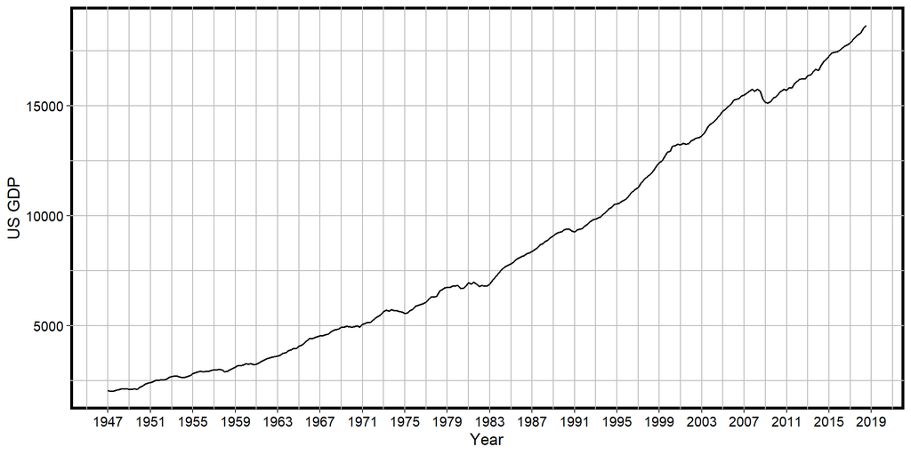

US quarterly GDP

```r
gdp_dt <- RtsaPkg::tsObj_to_dt(gdp_ts) %>%
  data.table::setnames(old=c("time","value"), new = c("Date","US_GDP"))
RplotterPkg::create_scatter_plot(
  df = gdp_dt,
  aes_x = "Date",
  aes_y = "US_GDP",
  x_major_date_breaks = "4 year",
  x_date_labels = "%Y",
  connect = TRUE,
  show_pts = FALSE,
  x_title = "Year",
  y_title = "US GDP",
  rot_y_tic_label = TRUE
)
```

### 3.2.1 Multivariate time series objects

> The multiple time series object (class: “mts”) is a combination of “ts” and “matrix” classes.

```r
econ_mts <- astsa::econ5
base::cat("econ_mts class: ", class(econ_mts), "\n")
```

```
econ_mts class:  mts ts matrix
```

```r
RplotterPkg::create_table(
  x = RtsaPkg::get_series_info(econ_mts, n_obser = 8)$data,
  container_width_px = 600
)
```

Multiple Time series sample data for econ_mts

| cycle | time | unemp | gnp | consum | govinv | prinv |
| --- | --- | --- | --- | --- | --- | --- |
| 3 | 1948.50 | 3.9 | 1106.1 | 681.4 | 180.4 | 210.3 |
| 4 | 1948.75 | 3.6 | 1116.3 | 682.9 | 181.3 | 211.5 |
| 1 | 1949.00 | 3.7 | 1125.5 | 688.3 | 178.7 | 206.0 |
| 2 | 1949.25 | 4.3 | 1112.4 | 688.7 | 181.6 | 183.2 |
| 3 | 1949.50 | 5.3 | 1105.9 | 696.9 | 196.3 | 160.2 |
| 4 | 1949.75 | 6.7 | 1114.3 | 695.3 | 205.1 | 168.3 |
| 1 | 1950.00 | 7.9 | 1103.3 | 700.8 | 215.2 | 163.4 |
| 2 | 1950.25 | 6.5 | 1148.2 | 711.9 | 217.6 | 201.9 |

> “mts” inherits from the “matrix” class and contains a matrix like table

```r
base::cat("econ_mts frequency: ", stats::frequency(econ_mts), "\n")
```

```
econ_mts frequency:  4
```

```r
base::cat("econ_mts delta: ", stats::deltat(econ_mts), "\n")
```

```
econ_mts delta:  0.25
```

```r
base::cat("econ_mts time: ", head(stats::time(econ_mts)), "\n")
```

```
econ_mts time:  1948.5 1948.75 1949 1949.25 1949.5 1949.75
```

```r
base::cat("econ_mts cycles: ", head(stats::cycle(econ_mts)), "\n")
```

```
econ_mts cycles:  3 4 1 2 3 4
```

```r
base::cat("econ_mts start: ", stats::start(econ_mts), "\n")
```

```
econ_mts start:  1948 3
```

```r
base::cat("econ_mts end: ", stats::end(econ_mts))
```

```
econ_mts end:  1988 3
```

Prerequisities for merging two “ts” into “mts”: 1. Inputs are regular time series 2. Inputs have exactly same frequency or time interval between observations 3. Inputs start at same cycle number and cycle unit

### 3.2.2 Creating a “ts” object

The `stats::ts()` function allows creating a “ts” object.

Create a monthly series with values from 1 to 60 beginning on January 2010.

- Attributes include:
  - Frequency = 12
  - Cycle = a year with frequency units of months
  - Start = frequency unit 1 (January) with cycle unit 2010
  - End = frequency unit 12 (December) with cycle unit 2014

```r
my_ts_1 <- stats::ts(
  data = 1:60, # series values
  start = c(2010,1), # time of the first observation
  end = c(2014,12), # time of the last observation
  frequency = 12 # the series frequency
)
```

```r
RplotterPkg::create_table(
  x = RtsaPkg::get_series_info(my_ts_1)$data,
  container_width_px = 400
)
```

ts object created via attributes

| cycle | time | my_ts_1 |
| --- | --- | --- |
| 1 | 2010.000 | 1 |
| 2 | 2010.083 | 2 |
| 3 | 2010.167 | 3 |
| 4 | 2010.250 | 4 |
| 5 | 2010.333 | 5 |
| 6 | 2010.417 | 6 |
| 7 | 2010.500 | 7 |
| 8 | 2010.583 | 8 |
| 9 | 2010.667 | 9 |
| 10 | 2010.750 | 10 |
| 11 | 2010.833 | 11 |
| 12 | 2010.917 | 12 |
| 1 | 2011.000 | 13 |

Convert a “data.frame” object (`US_indicators`) to a `ts`” time series object.

```r
apath <- file.path(here::here(), "Hands-on Time Series Analysis with R", "data", "US_indicators.rda")
base::load(apath)
str(US_indicators)
```

```
'data.frame':   528 obs. of  3 variables:
 $ Date             : Date, format: "1976-01-31" "1976-02-29" ...
 $ Vehicle Sales    : num  885 995 1244 1191 1203 ...
 $ Unemployment Rate: num  8.8 8.7 8.1 7.4 6.8 8 7.8 7.6 7.4 7.2 ...
```

We will use the *US_indicators$Vehicle Sales* vector as the data for the new `ts` time series object .

Since the input series is monthly we need to define the cycle(year) and frequency(month) units of the first observation:

`start = c(1976, 1)`

We can define a `ts` object by defining the data, the start point and the frequency:

```r
sales_ts <- ts(
  data = US_indicators$`Vehicle Sales`,
  start = c(1976, 1),
  frequency = 12
)
```

```r
RplotterPkg::create_table(
  x = RtsaPkg::get_series_info(sales_ts)$data,
  container_width_px = 400
)
```

US_indicators$Vehicle_Sales converted to “ts” object

| cycle | time | sales_ts |
| --- | --- | --- |
| 1 | 1976.000 | 885.2 |
| 2 | 1976.083 | 994.7 |
| 3 | 1976.167 | 1243.6 |
| 4 | 1976.250 | 1191.2 |
| 5 | 1976.333 | 1203.2 |
| 6 | 1976.417 | 1254.7 |
| 7 | 1976.500 | 1162.3 |
| 8 | 1976.583 | 1026.1 |
| 9 | 1976.667 | 1057.9 |
| 10 | 1976.750 | 1129.4 |
| 11 | 1976.833 | 1084.4 |
| 12 | 1976.917 | 1061.8 |
| 1 | 1977.000 | 969.9 |

### 3.2.3 Creating a *mts* object

Join both vehicle sales and unemployment rate series’ from *US_indicators* into an “mts” object.

Set the *data*, *start*, and *frequency* as we did above

```r
US_indicators_mts <- ts(
  data = US_indicators[, c("Vehicle Sales", "Unemployment Rate")],
  start = c(1976, 1),
  frequency = 12
)
```

```r
RplotterPkg::create_table(
  x = RtsaPkg::get_series_info(US_indicators_mts)$data,
  container_width_px = 400
)
```

Vehicle_Sales and Unemployment Rate as data for a converted multiple “mts” time series object

| cycle | time | Vehicle Sales | Unemployment Rate |
| --- | --- | --- | --- |
| 1 | 1976.000 | 885.2 | 8.8 |
| 2 | 1976.083 | 994.7 | 8.7 |
| 3 | 1976.167 | 1243.6 | 8.1 |
| 4 | 1976.250 | 1191.2 | 7.4 |
| 5 | 1976.333 | 1203.2 | 6.8 |
| 6 | 1976.417 | 1254.7 | 8.0 |
| 7 | 1976.500 | 1162.3 | 7.8 |
| 8 | 1976.583 | 1026.1 | 7.6 |
| 9 | 1976.667 | 1057.9 | 7.4 |
| 10 | 1976.750 | 1129.4 | 7.2 |
| 11 | 1976.833 | 1084.4 | 7.4 |
| 12 | 1976.917 | 1061.8 | 7.4 |
| 1 | 1977.000 | 969.9 | 8.3 |

### 3.2.4 Setting the series frequency

- Calculation of series freqency can be divided into two groups:
  - a daily frequency derived from the number of days in calendar year (weeks, hours, minutes in year)
  - any other frequency not derived from number of days

Create a data.frame with daily time over 10 years:

```r
daily_dt <- data.table::data.table(
  date = seq.Date(as.Date("2010-01-01"), length.out = 365 * 10, by = "day"),
  y = rnorm(365 * 10, mean = 15, sd = 2)
)
str(daily_dt)
```

```
Classes 'data.table' and 'data.frame':  3650 obs. of  2 variables:
 $ date: Date, format: "2010-01-01" "2010-01-02" ...
 $ y   : num  14.5 14.6 11.9 16.8 15.2 ...
 - attr(*, ".internal.selfref")=<externalptr>
```

We want to create “ts” object with a weekly cycle which suggests a frequency of the series to be set to 7:

```r
days_week_ts <- ts(
  data = daily_dt$y,
  start = c(1, lubridate::wday(min(daily_dt$date))),
  frequency = 7
)
```

```r
RplotterPkg::create_table(
  x = RtsaPkg::get_series_info(series = days_week_ts)$data,
  container_width_px = 400
)
```

Setting the frequency to 7 for a weekly cycle of daily random data.

| cycle | time | days_week_ts |
| --- | --- | --- |
| 6 | 1.714286 | 14.492165 |
| 7 | 1.857143 | 14.590554 |
| 1 | 2.000000 | 11.907929 |
| 2 | 2.142857 | 16.772954 |
| 3 | 2.285714 | 15.203606 |
| 4 | 2.428571 | 9.687284 |
| 5 | 2.571429 | 16.509649 |
| 6 | 2.714286 | 19.803178 |
| 7 | 2.857143 | 16.996792 |
| 1 | 3.000000 | 15.175640 |
| 2 | 3.142857 | 15.661485 |
| 3 | 3.285714 | 13.623338 |
| 4 | 3.428571 | 17.200853 |

For a yearly cycle of the daily we would set the frequency to 365 (ignoring leap year):

```r
days_year_ts <- ts(
  data = daily_dt$y,
  start = c(2010, lubridate::yday(min(daily_dt$date))),
  frequency = 365
)
```

```r
RplotterPkg::create_table(
  x = RtsaPkg::get_series_info(days_year_ts, n_obser = 6)$data,
  container_width_px = 400
)
```

Setting the frequency to 365 for a daily cycle of daily random data.

| cycle | time | days_year_ts |
| --- | --- | --- |
| 1 | 2010.000 | 14.492165 |
| 2 | 2010.003 | 14.590554 |
| 3 | 2010.005 | 11.907929 |
| 4 | 2010.008 | 16.772954 |
| 5 | 2010.011 | 15.203606 |
| 6 | 2010.014 | 9.687284 |

Setting the frequency to 365.25 to smooth the effect of leap year:

```r
days_year_leap_ts <- ts(
  data = daily_dt$y,
  start = c(2010, lubridate::yday(min(daily_dt$date))),
  frequency = 365.25
)
```

```r
RplotterPkg::create_table(
  x = RtsaPkg::get_series_info(days_year_leap_ts, n_obser = 6)$data,
  container_width_px = 400
)
```

Setting the frequency to 365.25 for a daily cycle accounting for leap year.

| cycle | time | days_year_leap_ts |
| --- | --- | --- |
| 1 | 2010.000 | 14.492165 |
| 2 | 2010.003 | 14.590554 |
| 3 | 2010.005 | 11.907929 |
| 4 | 2010.008 | 16.772954 |
| 5 | 2010.011 | 15.203606 |
| 6 | 2010.014 | 9.687284 |

```r
RplotterPkg::create_table(
  x = RtsaPkg::get_series_info(days_year_leap_ts, n_obser = 6)$stats,
  container_width_px = 500
)
```

Statistics from setting the frequency to 365.25 for a daily cycle accounting for leap year.

| name | class | delta | start | end | freq | length | nvar |
| --- | --- | --- | --- | --- | --- | --- | --- |
| days_year_leap_ts | ts | 0.002737851 | 2010 | 2019.99041752225 | 365.25 | 3650 | 1 |

## 3.3 Data manipulation of ts objects

### 3.3.1 The window function

The `stats::window()` function subsets a “ts” object based on a time range.

Use the function to extract the observations of the year 2005 from the USgas series.

Reread “USgas.rda” and show information for the original series.

```r
#|code-fold: true
#|tbl-cap: USgas time series statistics

apath <- file.path(here::here(), "Hands-on Time Series Analysis with R", "data", "USgas.rda")
load(apath)
RplotterPkg::create_table(
  x = RtsaPkg::get_series_info(series = USgas)$data,
  container_width_px = 400
)
```

| cycle | time | USgas |
| --- | --- | --- |
| 1 | 2000.000 | 2510.5 |
| 2 | 2000.083 | 2330.7 |
| 3 | 2000.167 | 2050.6 |
| 4 | 2000.250 | 1783.3 |
| 5 | 2000.333 | 1632.9 |
| 6 | 2000.417 | 1513.1 |
| 7 | 2000.500 | 1525.6 |
| 8 | 2000.583 | 1653.1 |
| 9 | 2000.667 | 1475.0 |
| 10 | 2000.750 | 1567.8 |
| 11 | 2000.833 | 1908.5 |
| 12 | 2000.917 | 2587.5 |
| 1 | 2001.000 | 2677.0 |

Get the series data for the year 2005

```r
window_2005_ts <- stats::window(
  x = USgas,
  start = c(2005,1),
  end = c(2005,12)
)
```

```r
RplotterPkg::create_table(
  x = RtsaPkg::get_series_info(series = window_2005_ts)$stats,
  container_width_px = 450
)
```

| name | class | delta | start | end | freq | length | nvar |
| --- | --- | --- | --- | --- | --- | --- | --- |
| window_2005_ts | ts | 0.08333333 | 2005 1 | 2005 12 | 12 | 12 | 1 |

Can get a specific frequency unit from the series. Extract all the observations of the series that occurred in October of the year:

```r
window_october_ts <- stats::window(
  x = USgas,
  start = c(2000, 10),
  frequency = 1
)
RplotterPkg::create_table(
  x = RtsaPkg::get_series_info(series = window_october_ts)$data,
  container_width_px = 400
)
```

| cycle | time | window_october_ts |
| --- | --- | --- |
| 1 | 2000.75 | 1567.8 |
| 1 | 2001.75 | 1649.1 |
| 1 | 2002.75 | 1645.9 |
| 1 | 2003.75 | 1553.2 |
| 1 | 2004.75 | 1557.2 |
| 1 | 2005.75 | 1428.2 |
| 1 | 2006.75 | 1644.2 |
| 1 | 2007.75 | 1627.8 |
| 1 | 2008.75 | 1635.8 |
| 1 | 2009.75 | 1666.5 |
| 1 | 2010.75 | 1664.9 |
| 1 | 2011.75 | 1744.5 |
| 1 | 2012.75 | 1901.1 |

Note: a frequency = 1 sets the output to a yearly series

### 3.3.2 Aggregating ts objects

The `stats::aggregate()` function is a generic function for aggregating “ts” and “data.frame” objects.

```r
USgas_year_ts <- stats::aggregate(USgas, nfrequency = 1, FUN = "sum")
USgas_year_ts
```

```
Time Series:
Start = 2000
End = 2018
Frequency = 1
 [1] 22538.6 22238.8 23027.0 22276.5 22402.5 22014.5 21699.2 23103.8 23276.9
[10] 22910.1 24086.8 24477.4 25538.6 26155.2 26593.4 27243.7 27444.3 27145.9
[19] 30075.3
```

### 3.3.3 Creating lags and leads for ts objects

The `stats::lag()` and `stats::lead()`can be used to create lags and leads.

Create a seasonal lag of USgas:

```r
USgas_lag4_ts <- stats::lag(USgas, k = -4)
RplotterPkg::create_table(
  x = RtsaPkg::get_series_info(series = USgas_lag4_ts)$stats,
  container_width_px = 450
)
```

| name | class | delta | start | end | freq | length | nvar |
| --- | --- | --- | --- | --- | --- | --- | --- |
| USgas_lag4_ts | ts | 0.08333333 | 2000 5 | 2020 2 | 12 | 238 | 1 |

```r
RplotterPkg::create_table(
  x = RtsaPkg::get_series_info(series = USgas)$stats,
  container_width_px = 400
)
```

| name | class | delta | start | end | freq | length | nvar |
| --- | --- | --- | --- | --- | --- | --- | --- |
| USgas | ts | 0.08333333 | 2000 1 | 2019 10 | 12 | 238 | 1 |

The fifth month of 2000 is the lag start; the second month in 2020 is the lag end.

## 3.4 Visualizing ts and mts objects